# Introduction

## VOC theory

On the country scale of United States, it would be be classified as Liberal Market Economies while, while in the state scale, it likely to be a CME model.

## Research question

According to the VoC theory, the United States is defined as liberal market economies and one characteristic of this model is that the union density is proportional to the vocational training level. While, the previous model contains 9 variables from dataset and defined as a linear model shows below:

The summary of the model shows to the coefficient, p-value, and other useful information.

```
##
## Call:
## lm(formula = Highschool ~ Union_density + GDP + Urbanity + Population +
##     Export + Unemployment_rate + Cost_of_living + Gini, data = data3)
##
## Residuals:
##     Min      1Q  Median      3Q     Max
## -261208  -64360  -25121   37190  514055
##
## Coefficients:
##                     Estimate Std. Error t value Pr(>|t|)
## (Intercept)        4.754e+05  5.014e+05   0.948  0.34852
## Union_density     -1.692e+04  5.694e+03  -2.971  0.00489 **
## GDP                6.629e-02  1.358e+00   0.049  0.96129
## Urbanity          -1.045e+03  1.826e+03  -0.572  0.57028
## Population         2.804e-02  3.834e-03   7.313  5.2e-09 ***
## Export            -5.176e-01  5.463e-01  -0.947  0.34882
## Unemployment_rate  1.909e+04  2.453e+04   0.778  0.44086
## Cost_of_living     1.241e+03  1.669e+03   0.743  0.46136
## Gini              -9.598e+05  1.142e+06  -0.840  0.40546
## ---
## Signif. codes:  0 '***' 0.001 '**' 0.01 '*' 0.05 '.' 0.1 ' ' 1
##
## Residual standard error: 144200 on 42 degrees of freedom
## Multiple R-squared:   0.67,  Adjusted R-squared:  0.6072
## F-statistic: 10.66 on 8 and 42 DF,  p-value: 5.037e-08
```

In the result, the coefficient of the high school is negative which means if union density arises, the high school would correspondingly decrease. This phenomenon apparently conflicts with properties of LME in VoC theory. A potential explaination comes that racial diversity in each state might leads to this result.

## Literature review

Market-baised management: Market-Based Management (MBM) enables organizations to succeed in the long term by applying the principles that allow free societies to prosper. Just as upholding values such as free speech, property rights, and progress is important to a healthy, growing society, it is also pivotal in fostering a healthy, growing organization.

Nation-level/state level: US is called LME because its national governing framework does not has institutions that aggregate preference for public goods, such as high-skill development.

## Dataset interpretation

**Descriptions:** Dataset details: -51 observations(51 states in US) and 31 variables. -Dependent variables included in the model: high school (represent vocational level). -Independent variables included in the model: union density, racial(white/black/hispanic), GDP, Urbanity, Population, Export, Cost of Living, Unemployment Rate, Gini

## Briefly introduce the methodology that we are going to use

According to the question presented, next following things needs to be done: Data check, Conducting the initial EDA(exploratory data analysis) and model check.  
- In the initial EDA part, scatterplots and bubble plot are presented to show the rough corelationship between union density and vocational training to get the general idea of the question.  
-Partial corelation test has been used to check if there still exists significant negative relationship between two variables when control the other 7 confounding variables.  
-Making some adjustment for the model to get more valuable results.  
-Drawing the component residual plot(CR plot) to check if the linear relationship and accordingly make sure that our adjusted models fitted well.  
-To better measure the racial diversity, a new variable based on White/Black/Hispanic is created.

# Data Check

**Concerns:** -Sources: Bureau of Labor Statistics wikipedia U.S. Census Bureau Census Bureau’s March Current Population Survey -Years: from 2016 to 2018 After looking through the source some issues were found that data is collected from several different source and years, so there comes worries that this data is so effective enough because these variables might have no consistency. It is more helpful to do the data analyze if data is more consistent.

-Variables: Checking 9 variables included in the model, the variable high school stands for the vocational training level. Cause on the state scale, US government needs more fundings to satisfy their supply and demand, so the high school is representitive but it’s better to include more sites such as high technology company, some industries which could contain vocational training people to satisfy their supply and demand as well. It will make more sense to add other potential sites in this variable. Additionally, the variables white/black/hispanic could not show the racial diversity directly,therefore, a new variables based on these three variables is created and will be discussed later in this report.

# Exploratory Data Analysis

- Not a distinguish negative coefficient between vocational training and union density

[figure not shown]

Starting with union density and high school and accordingly reach a scatter plot after cleaning some outliers. While from this plot shows there is not an obvious relationship between these two variables.

[figure not shown]

Moreover, a bubble plot is presented. Same as former plot, seting the union density as independent variable and high school as dependent variable, but this time replacing every spot with a circle, each circle represents for one state and the radius of a circle are standing for racial diversity level. The more racial diversity level, the larger circle is. While, by obverting this plot we could not confirm these two variables has negative relationship either.

To better understand this question, a research on the model is conducted and next session will describe this part detailedly.

# Methodology and Result

### Replicate Original Model

```
##
## Call:
## lm(formula = Highschool ~ Union_density + GDP + Urbanity + Population +
##     Export + Unemployment_rate + Cost_of_living + Gini, data = data3)
##
## Residuals:
##     Min      1Q  Median      3Q     Max
## -261208  -64360  -25121   37190  514055
##
## Coefficients:
##                     Estimate Std. Error t value Pr(>|t|)
## (Intercept)        4.754e+05  5.014e+05   0.948  0.34852
## Union_density     -1.692e+04  5.694e+03  -2.971  0.00489 **
## GDP                6.629e-02  1.358e+00   0.049  0.96129
## Urbanity          -1.045e+03  1.826e+03  -0.572  0.57028
## Population         2.804e-02  3.834e-03   7.313  5.2e-09 ***
## Export            -5.176e-01  5.463e-01  -0.947  0.34882
## Unemployment_rate  1.909e+04  2.453e+04   0.778  0.44086
## Cost_of_living     1.241e+03  1.669e+03   0.743  0.46136
## Gini              -9.598e+05  1.142e+06  -0.840  0.40546
## ---
## Signif. codes:  0 '***' 0.001 '**' 0.01 '*' 0.05 '.' 0.1 ' ' 1
##
## Residual standard error: 144200 on 42 degrees of freedom
## Multiple R-squared:   0.67,  Adjusted R-squared:  0.6072
## F-statistic: 10.66 on 8 and 42 DF,  p-value: 5.037e-08
```

[output not shown]

### Partial Correlation for Original Model

Then using the partial correlation test for checking if the negative relationship between Union density and Highschool exists in the primary model. The partial correlation is a measure of the strength and direction of a linear relationship between two continuous variables while controlling for the effect of other continuous variables.

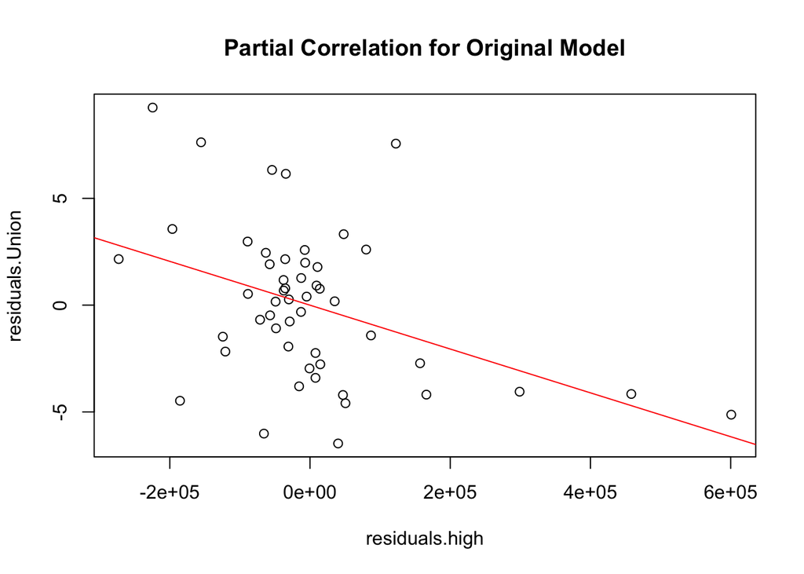

By controlling the seven confounding variables in the primary model, we used two methods on this test. One is the Pearson method, which evaluates the linear relationship between two continuous variables. A relationship is linear when a change in one variable is associated with a proportional change in the other variable. Another is the Spearman method, which evaluates the monotonic relationship between two continuous or ordinal variables. In a monotonic relationship, the variables tend to change together, but not necessarily at a constant rate, and both variables change together does not mean a change in one variable change causes another variable change.

Pearson Method

```
## [1] -0.4167175
```

```
## [1] 0.002351165
```

Spearman Method

```
## [1] -2.7575
```

```
## [1] 0.008161668
```

From the output of two methods, those correlations are negative, and P-values are small, which indicates that the negative coefficient of Union density is statistical significance in the primary model. From the plot on residual of Union density and residual of Highschool, the red line has an apparent downward trend. However, by looking at the points on the graph, there is a point in the lower right corner.

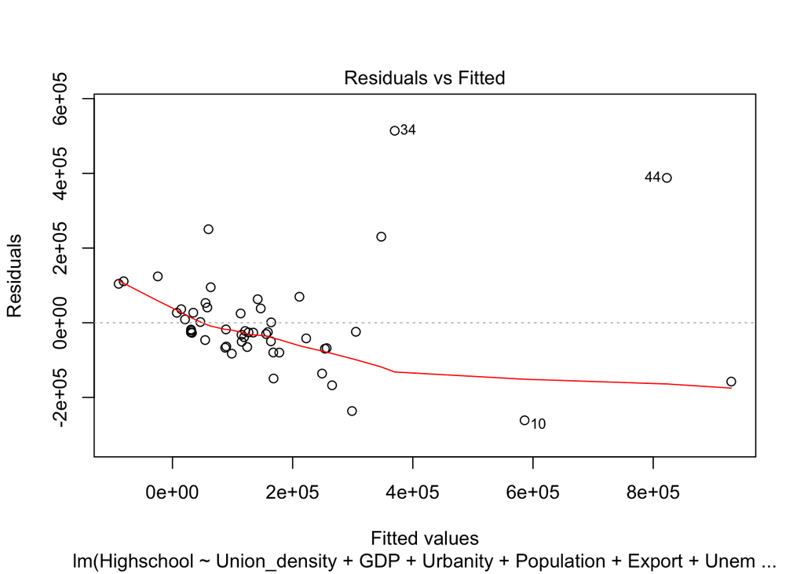

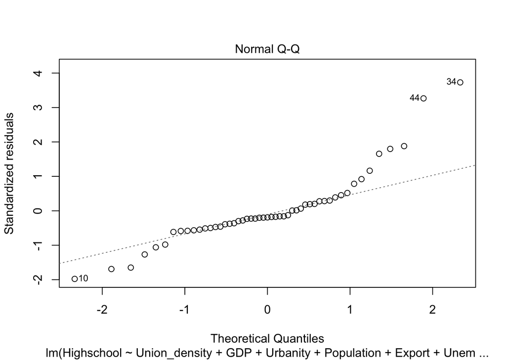

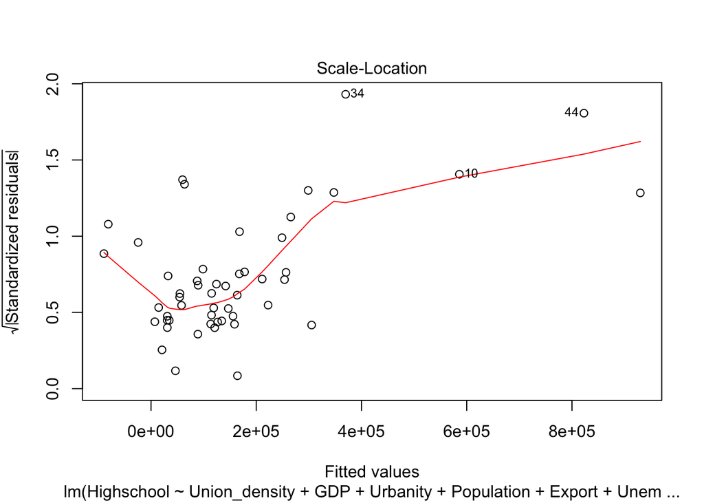

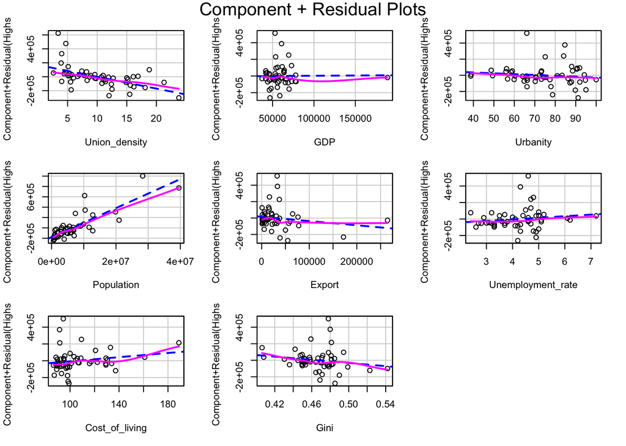

- Get the same coefficient
- Model validation

# Transformation

- Use CrPlots to determin which variable to take log transformation
- Model validation

```
##
## Call:
## lm(formula = log(Highschool) ~ Union_density + log(GDP) + Urbanity +
##     log(Population) + log(Export) + Unemployment_rate + log(Cost_of_living) +
##     Gini, data = data3)
##
## Residuals:
##     Min      1Q  Median      3Q     Max
## -1.8035 -0.3491  0.1601  0.3786  1.1588
##
## Coefficients:
##                      Estimate Std. Error t value Pr(>|t|)
## (Intercept)          5.198356   6.701335   0.776    0.442
## Union_density       -0.043265   0.027298  -1.585    0.120
## log(GDP)            -0.438462   0.545691  -0.803    0.426
## Urbanity             0.007762   0.009767   0.795    0.431
## log(Population)      0.950302   0.146685   6.479 8.14e-08 ***
## log(Export)         -0.005278   0.092754  -0.057    0.955
## Unemployment_rate    0.018547   0.112717   0.165    0.870
## log(Cost_of_living) -0.632347   0.983668  -0.643    0.524
## Gini                -1.585547   5.110432  -0.310    0.758
## ---
## Signif. codes:  0 '***' 0.001 '**' 0.01 '*' 0.05 '.' 0.1 ' ' 1
##
## Residual standard error: 0.6602 on 42 degrees of freedom
## Multiple R-squared:  0.7649, Adjusted R-squared:  0.7202
## F-statistic: 17.09 on 8 and 42 DF,  p-value: 5.888e-11
```

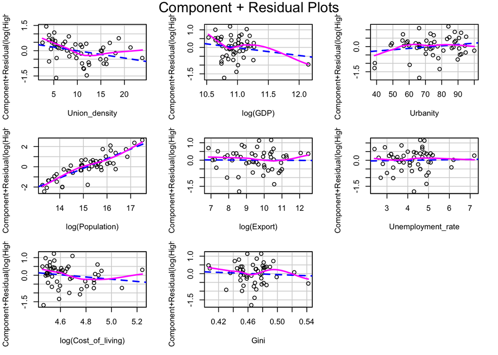

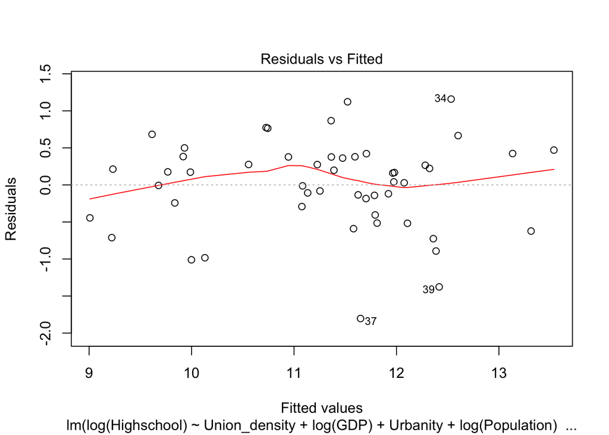

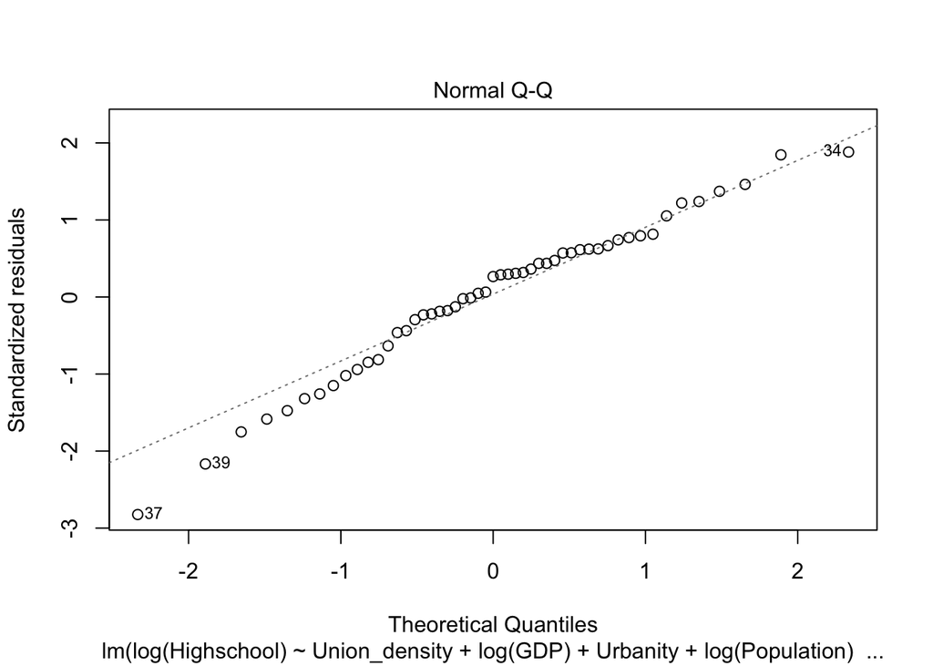

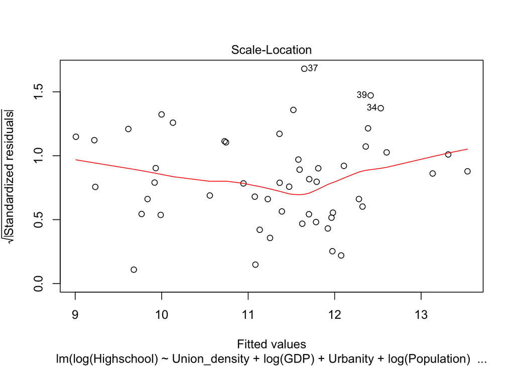

After modeling, residual plots are generated to check the validation of the model. Looking at the residual plot, nearly all the residuals are equally distributed within the horizontal line valued at zero, indicating that the residuals are random, and the linearity assumption is satisfied. Looking at the Q-Q plot, majority of the residual points are aligned with the straight line, indicating the normality assumption is nearly satisfied. Looking at the scale-location plot, most residues are spread equally along the ranges of predictors, indicating the equal variance assumption is satisfied. Based on the residual plot, the model “fit1” is more valid compared to the original model. Check the component and residual plot again, the issue regarding the leverage points have been improved a lot. But two issues still have to be considered. First, there is a leverage point in GDP after taking log transformation. Second, the variable of union density slightly shows a curved pattern, indicating that linear assumption is not well satisfied, and a more robust model might be considered.

```
##
## Call:
## lm(formula = log(Highschool) ~ Union_density + log(GDP) + Urbanity +
##     log(Population) + log(Export) + Unemployment_rate + log(Cost_of_living) +
##     Gini, data = data4)
##
## Residuals:
##      Min       1Q   Median       3Q      Max
## -1.77486 -0.31688  0.03988  0.41357  1.16933
##
## Coefficients:
##                      Estimate Std. Error t value Pr(>|t|)
## (Intercept)         -2.757715   8.934208  -0.309   0.7591
## Union_density       -0.059829   0.029775  -2.009   0.0511 .
## log(GDP)             0.119772   0.684302   0.175   0.8619
## Urbanity             0.007271   0.009686   0.751   0.4571
## log(Population)      0.889431   0.152379   5.837 7.38e-07 ***
## log(Export)         -0.008890   0.091954  -0.097   0.9234
## Unemployment_rate    0.052305   0.114538   0.457   0.6503
## log(Cost_of_living) -0.397213   0.990627  -0.401   0.6905
## Gini                 2.270601   5.834118   0.389   0.6991
## ---
## Signif. codes:  0 '***' 0.001 '**' 0.01 '*' 0.05 '.' 0.1 ' ' 1
##
## Residual standard error: 0.6542 on 41 degrees of freedom
## Multiple R-squared:  0.7502, Adjusted R-squared:  0.7014
## F-statistic: 15.39 on 8 and 41 DF,  p-value: 3.764e-10
```

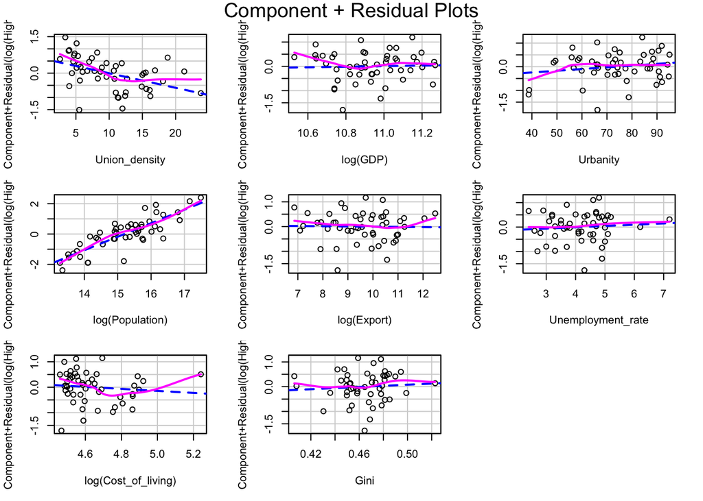

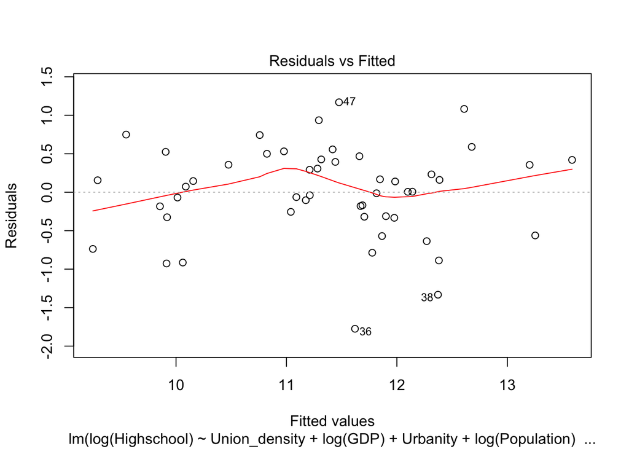

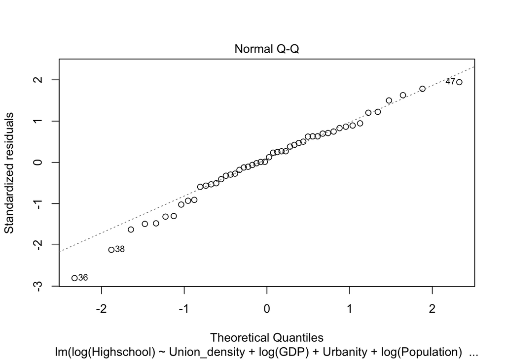

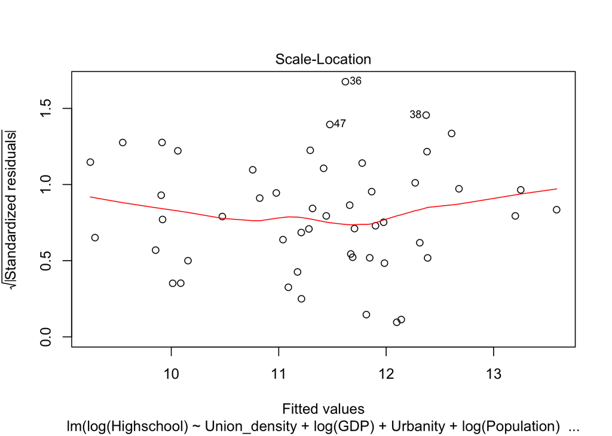

### Partial Correlation for Transformed Model

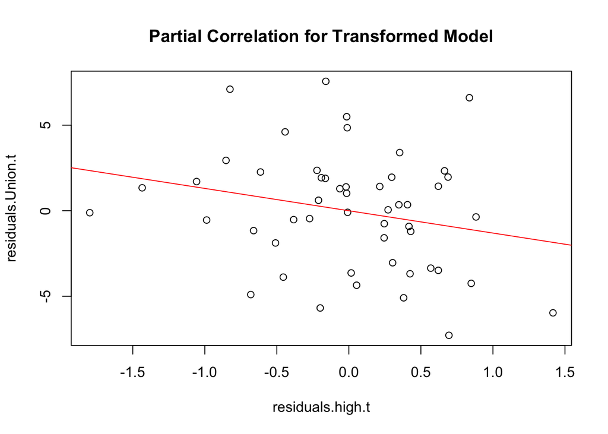

By checking the partial correlation of transformed model, the red line is flatter than in the original model.

Pearson Method

```
## [1] -0.2375583
```

```
## [1] 0.09323562
```

Spearman Method

```
## [1] -0.2179186
```

```
## [1] 0.1244902
```

By checking the output from two methods, the partial correlations between Union density and Vocational training are smaller, and P-values are larger. Thus, in the transformed model, the negative relationship between the two factors is not as strong as in the original model.

# Adding Racial Diversity

The final model is adding racial diversity to the transformed model since the main question is if racial diversity can explain the negative effect between unionization and vocational training.

The data frame only contains the proportion of Black, White, and Hispanic. First of all, by using the formula from the article “How to Measure Density When You Must,” calculating the proportion of same race which equals to the sum square Black, square White adds, and square Hispanic, then the proportion of different race equals to one minus the proportion of same race. However, in the real world, different states may have different types of races, and different types of the race will affect the result of racial diversity. To alleviate this kind of problem that can arise when modeling, racial diversity needs to be normalized before adding to the model. Times the radical diversity by C/(C-1) can get the normalized racial diversity, C means the total type of race. In this case, C is 3.

$$Racial Diversity = 1 - (Black^2 + White^2 + Hispanic^2)$$
$$NormRacialDiversity = \frac{C}{C-1}*Racial Diversity$$

```
##
## Call:
## lm(formula = log(Highschool) ~ Union_density + log(GDP) + Urbanity +
##     log(Population) + log(Export) + Unemployment_rate + log(Cost_of_living) +
##     Gini + norm_Racial_diversity, data = data3)
##
## Residuals:
##      Min       1Q   Median       3Q      Max
## -2.11000 -0.29731  0.02178  0.33166  1.05237
##
## Coefficients:
##                        Estimate Std. Error t value Pr(>|t|)
## (Intercept)            7.446738   6.396034   1.164   0.2510
## Union_density         -0.024490   0.026891  -0.911   0.3678
## log(GDP)              -0.053305   0.538701  -0.099   0.9217
## Urbanity              -0.006738   0.010946  -0.616   0.5416
## log(Population)        0.798928   0.151591   5.270 4.68e-06 ***
## log(Export)            0.097660   0.097082   1.006   0.3203
## Unemployment_rate     -0.130898   0.122559  -1.068   0.2918
## log(Cost_of_living)   -1.709210   1.026990  -1.664   0.1037
## Gini                  -1.011016   4.833292  -0.209   0.8353
## norm_Racial_diversity  1.590066   0.645692   2.463   0.0181 *
## ---
## Signif. codes:  0 '***' 0.001 '**' 0.01 '*' 0.05 '.' 0.1 ' ' 1
##
## Residual standard error: 0.6236 on 41 degrees of freedom
## Multiple R-squared:  0.7952, Adjusted R-squared:  0.7503
## F-statistic: 17.69 on 9 and 41 DF,  p-value: 1.711e-11
```

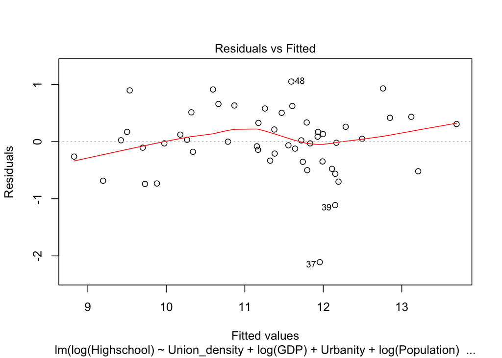

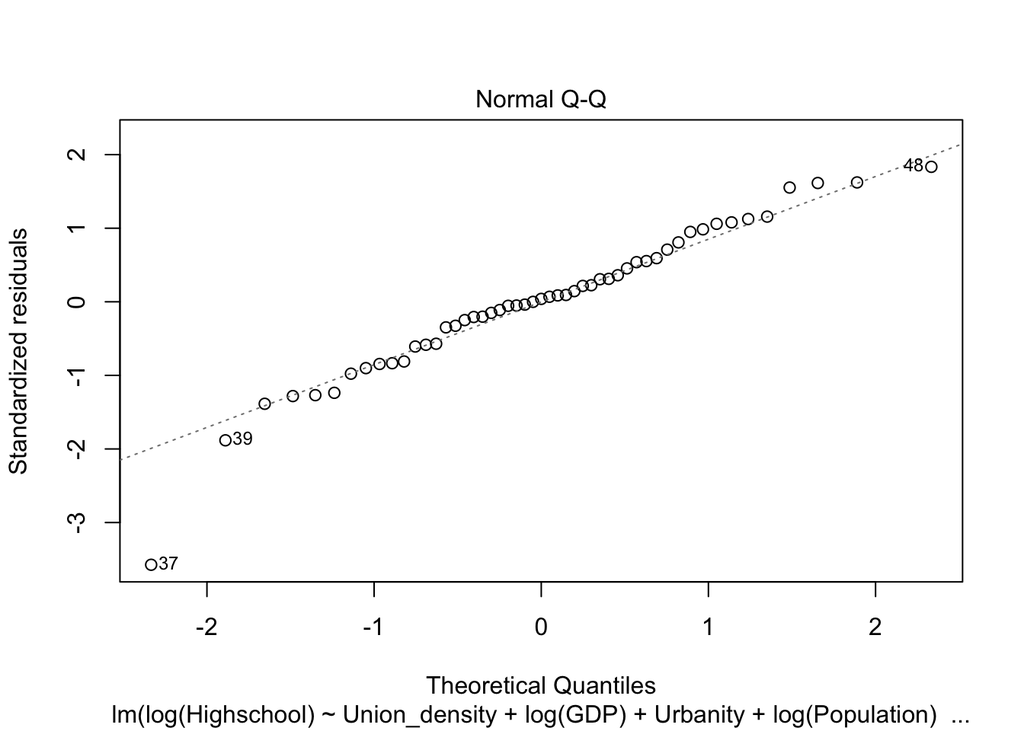

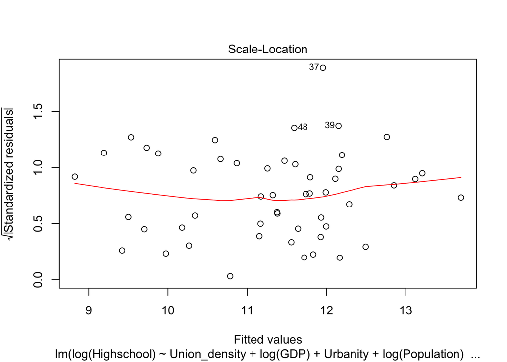

The assumptions of adding the normalized racial diversity model are similar to the transformed model; the only change is that adjusted R-squared increases a little bit, from 0.7202 to 0.7503. The adjusted R-squared is a modified version of R-squared and increases only if the new term improves model more than would be expected by chance. It decreases when a predictor improves the model by less than expected by chance. Therefore, after adding normalized racial diversity, the new model fits better than the transformed model.

### Partial Correlation for Third Model

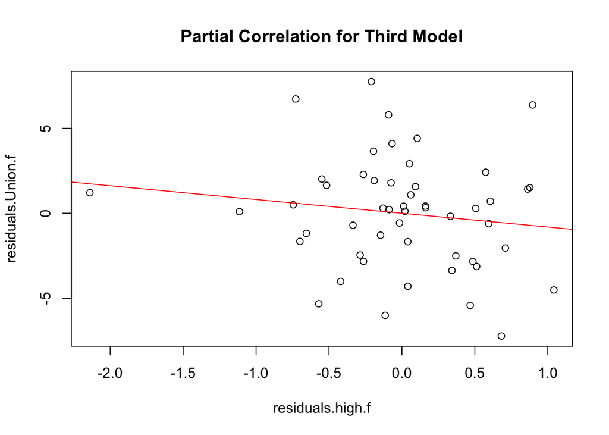

By checking the partial correlation of the third model, the red line is pretty close to the horizontal line.  
Pearson Method

```
## [1] -0.1242534
```

```
## [1] 0.3849993
```

Spearman Method

```
## [1] -0.1408109
```

```
## [1] 0.09939286
```